# Does freshwater-event context explain severe mortality misses?

Joint observation model and 2024 rainfall/calm-weather sensitivity

# Decision

The freshwater hypothesis receives **qualified rather than production-grade support**. ERA5 rainfall and calm conditions improve the joint BRT’s 2024 spatial predictions for manta tow, particularly at wet northern and central reefs. They do not improve transfer to a completely unseen event, do not help MMP, and the Bayesian model does not support a positive DHW–rainfall synergy.

Model promotion decision by prediction target

| candidate | prediction_target | status | reason |
| --- | --- | --- | --- |
| Joint compound BRMS | Future unseen event | Reject | Worse RMSE and severe MAE for all programmes; positive DHW-rainfall synergy not supported. |
| Joint compound BRT | Future unseen event | Reject | Weather improves some average errors but worsens severe-tail error and does not beat the routed benchmark. |
| Joint compound BRMS | 2024 spatial reconstruction | Reject | Does not improve manta or MMP severe spatial error over the formal benchmark. |
| Joint compound BRT | 2024 spatial reconstruction | Sensitivity only | Weather ablation improves manta spatial RMSE and severe MAE, but the gain is framework- and programme-specific. |

The existing programme-specific production route is therefore unchanged. The joint weather BRT is retained as a 2024 reconstruction sensitivity, not as the GBR-wide future-event predictor.

# What was tested

The joint dataset contains 537 observations and 306 unique reef-events. Of these, 152 reef-events are observed by two programmes. The Bayesian model uses shared ecological effects, a shared reef-event deviation, and programme-specific mean offsets, boundary probabilities, complete-loss probabilities, and precision.

The compact weather addition is deliberately limited to:

- ERA5 nearest-coastal maximum 30-day rainfall;
- ERA5 reef mean wind and fraction of calm hours below 3 m/s;
- distance to the coastal ERA5 cell;
- DHW by rainfall and DHW by calm-fraction interactions.

The partial January 2024 eReefs salinity record is not used as a predictor. Disturbance codes and descriptions are retained for interpretation but do not affect fitting or inclusion.

# Forecasting an unseen bleaching event

Leave-one-event-out performance

| Programme | Model | n | Severe n | RMSE | MAE | Predictive R2 | Severe MAE | Severe observed - predicted |
| --- | --- | --- | --- | --- | --- | --- | --- | --- |
| LTMP benthic | Current routed benchmark | 199 | 29 | 0.128 | 0.080 | 0.408 | 0.212 | 0.174 |
| LTMP benthic | Joint BRT with weather | 199 | 29 | 0.136 | 0.087 | 0.337 | 0.279 | 0.279 |
| LTMP benthic | Joint BRT without weather | 199 | 29 | 0.137 | 0.092 | 0.323 | 0.262 | 0.262 |
| LTMP benthic | Joint BRMS with weather | 199 | 29 | 0.150 | 0.096 | 0.188 | 0.324 | 0.324 |
| MMP inshore | Current routed benchmark | 90 | 35 | 0.216 | 0.142 | 0.129 | 0.207 | 0.159 |
| MMP inshore | Joint BRT without weather | 90 | 35 | 0.292 | 0.199 | -0.590 | 0.335 | 0.288 |
| MMP inshore | Joint BRT with weather | 90 | 35 | 0.302 | 0.214 | -0.692 | 0.342 | 0.257 |
| MMP inshore | Joint BRMS with weather | 90 | 35 | 0.324 | 0.232 | -0.951 | 0.347 | 0.238 |
| Manta tow | Current routed benchmark | 248 | 56 | 0.141 | 0.105 | 0.169 | 0.221 | 0.216 |
| Manta tow | Joint BRT with weather | 248 | 56 | 0.152 | 0.104 | 0.029 | 0.251 | 0.248 |
| Manta tow | Joint BRMS with weather | 248 | 56 | 0.158 | 0.113 | -0.046 | 0.275 | 0.270 |
| Manta tow | Joint BRT without weather | 248 | 56 | 0.158 | 0.113 | -0.055 | 0.240 | 0.237 |

The current routed benchmark remains best. In manta tow, the weather BRT has RMSE 0.152 versus 0.141 for the benchmark, while severe MAE increases from 0.221 to 0.251. The joint BRMS is poorer again. Freshwater context therefore cannot yet be used to forecast the severity of a novel event from historical events alone.

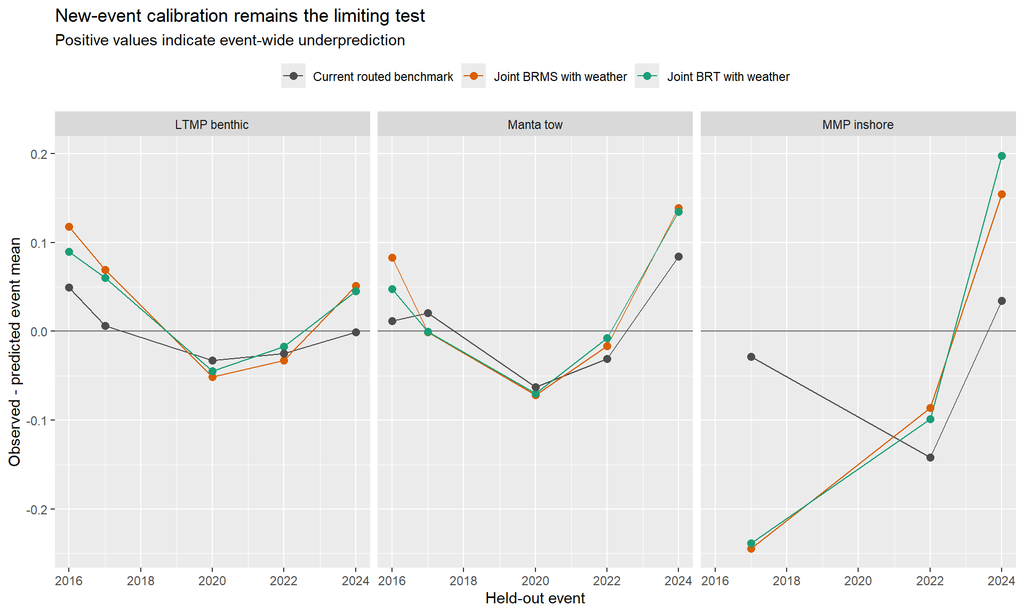

# Mapping 2024 after the event is represented

Strict reef-blocked reconstruction of 2024

| Programme | Model | n | Severe n | RMSE | MAE | Predictive R2 | Severe MAE | Severe observed - predicted | Non-severe MAE |
| --- | --- | --- | --- | --- | --- | --- | --- | --- | --- |
| LTMP benthic | Formal spatial benchmark | 75 | 12 | 0.110 | 0.078 | 0.506 | 0.187 | 0.179 | 0.0566786 |
| LTMP benthic | Joint BRMS with weather | 75 | 12 | 0.112 | 0.088 | 0.485 | 0.161 | 0.142 | 0.0736968 |
| LTMP benthic | Joint BRT without weather | 75 | 12 | 0.115 | 0.085 | 0.455 | 0.155 | 0.155 | 0.0715890 |
| LTMP benthic | Joint BRT with weather | 75 | 12 | 0.116 | 0.088 | 0.451 | 0.144 | 0.142 | 0.0769773 |
| MMP inshore | Joint BRT without weather | 54 | 25 | 0.242 | 0.167 | 0.210 | 0.246 | 0.232 | 0.0996456 |
| MMP inshore | Joint BRMS with weather | 54 | 25 | 0.251 | 0.181 | 0.151 | 0.264 | 0.264 | 0.1095333 |
| MMP inshore | Joint BRT with weather | 54 | 25 | 0.251 | 0.176 | 0.150 | 0.247 | 0.225 | 0.1146175 |
| MMP inshore | Formal spatial benchmark | 54 | 25 | 0.263 | 0.192 | 0.068 | 0.231 | 0.172 | 0.1573341 |
| Manta tow | Joint BRT with weather | 89 | 39 | 0.151 | 0.121 | 0.284 | 0.165 | 0.145 | 0.0864582 |
| Manta tow | Formal spatial benchmark | 89 | 39 | 0.157 | 0.129 | 0.230 | 0.169 | 0.163 | 0.0973286 |
| Manta tow | Joint BRT without weather | 89 | 39 | 0.161 | 0.125 | 0.184 | 0.179 | 0.168 | 0.0832540 |
| Manta tow | Joint BRMS with weather | 89 | 39 | 0.175 | 0.136 | 0.044 | 0.200 | 0.164 | 0.0854616 |

For manta tow, adding weather to the joint BRT reduces spatial RMSE from 0.161 to 0.151 and severe MAE from 0.179 to 0.165. It also reduces LTMP severe MAE, but slightly worsens its overall error. MMP does not benefit.

Weather BRT minus core BRT; negative values are improvements

| Target | Programme | Delta RMSE | Delta severe MAE | Delta non-severe MAE |
| --- | --- | --- | --- | --- |
| Unseen event | LTMP benthic | -0.001 | 0.017 | -0.009 |
| Unseen event | Manta tow | -0.006 | 0.011 | -0.015 |
| Unseen event | MMP inshore | 0.009 | 0.007 | 0.020 |
| 2024 spatial reconstruction | LTMP benthic | 0.000 | -0.011 | 0.005 |
| 2024 spatial reconstruction | Manta tow | -0.010 | -0.014 | 0.003 |
| 2024 spatial reconstruction | MMP inshore | 0.009 | 0.001 | 0.015 |

# Is the effect a DHW interaction?

All-event joint BRMS weather posterior

| Effect | Estimate | 2.5% | 97.5% | P(ecological direction) |
| --- | --- | --- | --- | --- |
| Rainfall main effect on positive mortality | 0.381 | 0.173 | 0.596 | 1.000 |
| DHW x rainfall on positive mortality | -0.102 | -0.270 | 0.065 | 0.118 |
| Calm main effect on positive mortality | 0.135 | -0.225 | 0.488 | 0.775 |
| DHW x calm on positive mortality | -0.118 | -0.280 | 0.043 | 0.076 |
| Rainfall main effect on zero inflation | -0.157 | -0.408 | 0.085 | 0.890 |
| DHW x rainfall on zero inflation | 0.151 | -0.072 | 0.391 | 0.102 |
| Calm main effect on zero inflation | -0.349 | -0.808 | 0.092 | 0.937 |
| DHW x calm on zero inflation | -0.016 | -0.244 | 0.204 | 0.558 |

Rainfall has a clear positive **main effect** on positive mortality. It also tends to reduce zero inflation, making some mortality more likely. In contrast, the positive DHW–rainfall synergy has posterior probability only 0.118 in the magnitude component and 0.102 in the boundary component. Calm conditions show the same broad pattern but with much greater uncertainty.

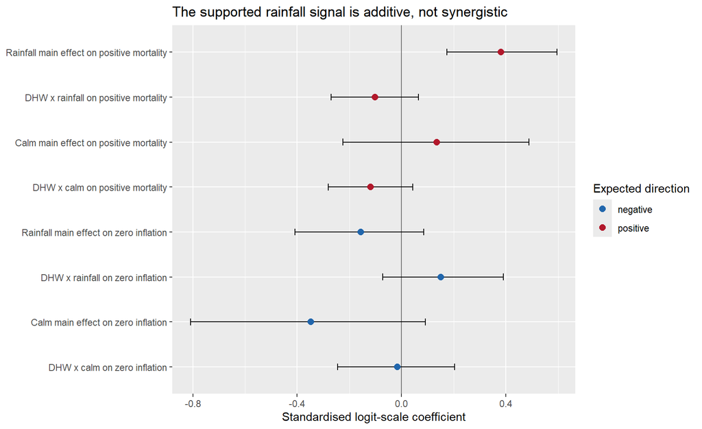

# Which severe manta reefs respond to weather?

2024 severe manta mortality by region and model

| Model | Region | n | Observed | Predicted | Severe MAE | Observed - predicted |
| --- | --- | --- | --- | --- | --- | --- |
| Formal spatial benchmark | Central GBR | 9 | 0.332 | 0.159 | 0.174 | 0.173 |
| Formal spatial benchmark | Northern GBR | 10 | 0.399 | 0.208 | 0.191 | 0.191 |
| Formal spatial benchmark | Southern GBR | 20 | 0.356 | 0.211 | 0.155 | 0.145 |
| Joint BRMS with weather | Central GBR | 9 | 0.332 | 0.189 | 0.180 | 0.143 |
| Joint BRMS with weather | Northern GBR | 10 | 0.399 | 0.122 | 0.278 | 0.278 |
| Joint BRMS with weather | Southern GBR | 20 | 0.356 | 0.240 | 0.171 | 0.117 |
| Joint BRT with weather | Central GBR | 9 | 0.332 | 0.190 | 0.160 | 0.143 |
| Joint BRT with weather | Northern GBR | 10 | 0.399 | 0.210 | 0.189 | 0.189 |
| Joint BRT with weather | Southern GBR | 20 | 0.356 | 0.233 | 0.155 | 0.123 |
| Joint BRT without weather | Central GBR | 9 | 0.332 | 0.155 | 0.179 | 0.177 |
| Joint BRT without weather | Northern GBR | 10 | 0.399 | 0.173 | 0.227 | 0.227 |
| Joint BRT without weather | Southern GBR | 20 | 0.356 | 0.222 | 0.155 | 0.135 |

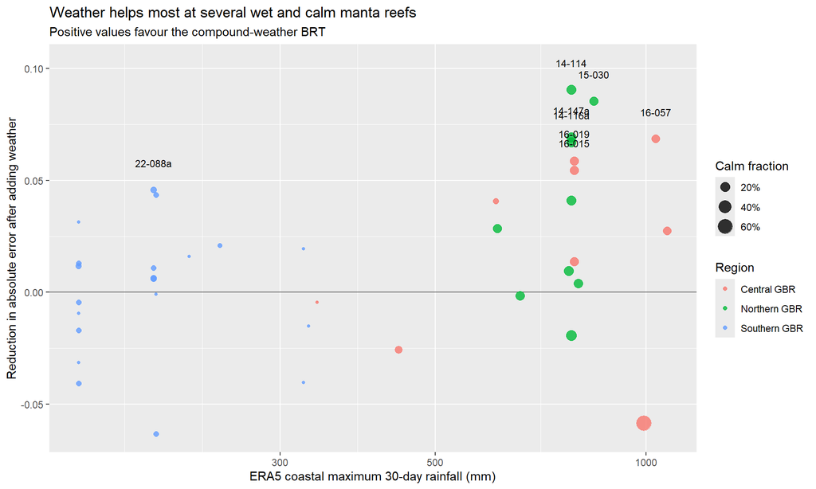

Severe manta reefs ranked by weather-related error reduction

| Reef | Region | DHW | Observed | Formal spatial | Core joint BRT | Weather joint BRT | Joint BRMS | Rain 30d (mm) | Calm fraction | Weather error reduction | Disturbance | Notes |
| --- | --- | --- | --- | --- | --- | --- | --- | --- | --- | --- | --- | --- |
| MacGillivray Reef (14-114) | Northern GBR | 5.93 | 0.389 | 0.202 | 0.172 | 0.262 | 0.156 | 781 | 20% | 0.090 | b | DHW 6.03 |
| Swinger Reef (15-030) | Northern GBR | 3.87 | 0.346 | 0.164 | 0.061 | 0.146 | 0.127 | 841 | 15% | 0.085 | b | DHW 3.87 |
| South Direction Reef (North) (14-147a) | Northern GBR | 6.40 | 0.223 | 0.115 | 0.143 | 0.213 | 0.093 | 781 | 20% | 0.069 | b | DHW 6.4 aerial bl 5 |
| Hastings Reef (16-057) | Central GBR | 7.62 | 0.429 | 0.121 | 0.048 | 0.116 | 0.131 | 1033 | 13% | 0.068 | m | Jasper |
| Lizard Island Reef (North West) (14-116a) | Northern GBR | 6.27 | 0.462 | 0.191 | 0.101 | 0.168 | 0.079 | 781 | 20% | 0.067 | b | DHW 6.27 aerial bl 4 |
| St Crispin Reef (16-019) | Central GBR | 5.87 | 0.207 | 0.125 | 0.137 | 0.220 | 0.093 | 789 | 15% | 0.059 | m | DHW 6.98 |
| Mackay Reef (16-015) | Central GBR | 3.52 | 0.613 | 0.147 | 0.129 | 0.183 | 0.116 | 789 | 15% | 0.055 | NA | NA |
| U/N Reef (22-088a) | Southern GBR | 7.58 | 0.340 | 0.147 | 0.081 | 0.127 | 0.051 | 198 | 5% | 0.046 | NA | NA |
| Broomfield Reef (23-048) | Southern GBR | 11.60 | 0.571 | 0.270 | 0.388 | 0.431 | 0.440 | 200 | 3% | 0.044 | m | Aerial bl 5 2024 DHW 11.6 |
| Eyrie Reef (14-118) | Northern GBR | 6.27 | 0.526 | 0.239 | 0.238 | 0.280 | 0.159 | 781 | 20% | 0.041 | b | DHW 6.27 to 6.32 |
| Myrmidon Reef (18-034) | Central GBR | 8.73 | 0.364 | 0.119 | 0.095 | 0.136 | 0.178 | 611 | 4% | 0.041 | b | DHW 7.18 |
| U/N Reef (20-348) | Southern GBR | 8.39 | 0.320 | 0.212 | 0.084 | 0.116 | 0.057 | 155 | 1% | 0.031 | b | Aerial bl 3 2024 DHW 8.39 2024 |
| Mantis Reef (12-056) | Northern GBR | 8.73 | 0.264 | 0.116 | 0.155 | 0.184 | 0.120 | 613 | 15% | 0.028 | b | DHW 8.91 |
| Thetford Reef (16-068) | Central GBR | 7.34 | 0.221 | 0.130 | 0.094 | 0.121 | 0.136 | 1071 | 12% | 0.027 | b | Aerial bl 3 2024 DHW 7.63 2024 |
| One Tree Island Reef (23-055a) | Southern GBR | 11.53 | 0.511 | 0.362 | 0.463 | 0.484 | 0.583 | 246 | 2% | 0.021 | m | Aerial bl 4 2024 DHW 11.81 |
| Hoskyn Islands Reef (23-080) | Southern GBR | 11.20 | 0.548 | 0.531 | 0.362 | 0.381 | 0.552 | 324 | 1% | 0.019 | b | DHW 11.48 |
| Penrith Reef (21-025) | Southern GBR | 8.25 | 0.421 | 0.080 | 0.034 | 0.050 | 0.113 | 223 | 1% | 0.016 | NA | NA |
| Agincourt Reefs (No 1) (15-099c) | Central GBR | 6.97 | 0.236 | 0.237 | 0.165 | 0.292 | 0.165 | 789 | 15% | 0.014 | m | Aerial bl 3 2024 DHW 6.97 |
| U/N Reef (21-187) | Southern GBR | 7.25 | 0.442 | 0.215 | 0.248 | 0.261 | 0.132 | 155 | 3% | 0.013 | b | decline following bleaching |
| U/N Reef (21-529) | Southern GBR | 7.19 | 0.367 | 0.184 | 0.213 | 0.224 | 0.139 | 155 | 4% | 0.012 | b | Aerial bl 5 2024 DHW 7.19 2024 |
| Turner Reef (21-562) | Southern GBR | 9.27 | 0.315 | 0.095 | 0.147 | 0.157 | 0.112 | 198 | 3% | 0.011 | NA | NA |
| U/N Reef (13-124) | Northern GBR | 7.65 | 0.384 | 0.309 | 0.190 | 0.200 | 0.122 | 776 | 19% | 0.009 | b | DHW 7.65 |
| U/N Reef (22-084) | Southern GBR | 8.47 | 0.297 | 0.059 | 0.030 | 0.036 | 0.079 | 198 | 5% | 0.006 | NA | NA |
| U/N Reef (21-550) | Southern GBR | 7.85 | 0.311 | 0.160 | 0.182 | 0.188 | 0.176 | 198 | 5% | 0.006 | NA | NA |
| Tydeman Reef (13-133) | Northern GBR | 7.18 | 0.266 | 0.149 | 0.147 | 0.151 | 0.117 | 801 | 18% | 0.004 | b | Aerial bl 3 2024 DHW 7.18 |

Weather improves several northern and central reefs, including MacGillivray, Swinger, South Direction, Hastings, Lizard Island NW, St Crispin, Mackay and Eyrie. Hastings is explicitly associated with Jasper. The gain is not confined to recorded multiple disturbances, and substantial underprediction remains.

# Sampling diagnostics and interpretation boundary

Joint BRMS screening-fold diagnostics

| Target | Fold | Maximum R-hat | Minimum bulk ESS | Minimum tail ESS | Divergences | Tree-depth hits | Pass gate |
| --- | --- | --- | --- | --- | --- | --- | --- |
| reef_blocked_2024 | 1 | 1.034 | 149.329 | 317.387 | 0 | 0 | FALSE |
| reef_blocked_2024 | 2 | 1.017 | 187.998 | 199.534 | 0 | 0 | FALSE |
| reef_blocked_2024 | 3 | 1.014 | 190.327 | 359.804 | 0 | 0 | FALSE |
| reef_blocked_2024 | 4 | 1.011 | 179.416 | 241.851 | 0 | 0 | FALSE |
| reef_blocked_2024 | 5 | 1.020 | 153.513 | 267.051 | 0 | 0 | FALSE |
| leave_one_event_out | 2016 | 1.013 | 179.018 | 274.671 | 0 | 0 | FALSE |
| leave_one_event_out | 2017 | 1.012 | 200.539 | 280.639 | 0 | 0 | FALSE |
| leave_one_event_out | 2020 | 1.010 | 204.325 | 425.722 | 0 | 0 | TRUE |
| leave_one_event_out | 2022 | 1.017 | 219.057 | 366.981 | 0 | 0 | FALSE |
| leave_one_event_out | 2024 | 1.012 | 161.138 | 365.487 | 0 | 0 | FALSE |

Several two-chain screening folds exceed the strict R-hat gate, although none has divergences or tree-depth failures and the four-chain production fit passes. Because the candidate fails predictive promotion regardless, targeted refits would not change the decision and are not warranted at this stage.

The evidence currently supports rainfall/calm weather as an additive 2024 reconstruction sensitivity. It does not yet support calling the inferred effect measured salinity, imposing a positive DHW interaction, or changing the GBR-wide production route.